# Battery Survival Analysis

Initial Methods Exploration

Zach Aandahl

26/04/2021

## Data Exploration

The data used in this markdocument are dated 2021-04-21. The tables below summarise the primary variable of interest **Battery** with four categorical covariates to guide experimental design. The battery data will be subset by specific brands for each covariate if the levels across those brands contain enough samples for analysis.

**Battery - Flash Type**

COXPH - Flash Type, Battery (Procell, Varta)

```
##
##                w    i
##   Ansmann    202    0
##   Energizer  204    1
##   Maxell     193    0
##   Procell    731   33
##   Ultra      213    0
##   Varta     1145  202
##   Wallaby    226    0
```

**Battery - Battery Type**

Can examine lithium vs alkaline ignoring battery brand.

```
##
##             lithium alkaline
##   Ansmann       202        0
##   Energizer     205        0
##   Maxell        193        0
##   Procell         0      764
##   Ultra           0      213
##   Varta        1347        0
##   Wallaby       226        0
```

**Battery - Season**

COXPH - Season, Battery (Procell, Varta)

```
##
##             summer spring autumn winter
##   Ansmann       65     70     67      0
##   Energizer     77    128      0      0
##   Maxell        98      0      0     95
##   Procell      185    172    205    202
##   Ultra        185      0      0     28
##   Varta        497    398    287    165
##   Wallaby        0     33    106     87
```

**Battery - Region**

COXPH - Region, Battery (Varta)

```
##
##              ne  ct  se  nw  wt  sw
##   Ansmann     0  39  31  67  65   0
##   Energizer   0  77  60  68   0   0
##   Maxell      0   0   0   0   0 193
##   Procell     2 264 320   0 178   0
##   Ultra       0   0   0   0   0 213
##   Varta     564 182 154 147 206  94
##   Wallaby     0  33 106   0  87   0
```

## Survival Curves

**Semi-parametric (COXPH) vs Non-Parametric (Kaplan-Meier) Survival**

The solid lines show Kaplan-Meier survival estimates. The translucent thick lines show Cox Proportional-Hazard survival curves. The Cox curves largely follow the Kaplan-Meier survival curves with Maxell being an exception. Varta is the highest performing brand while Procell is the worst.

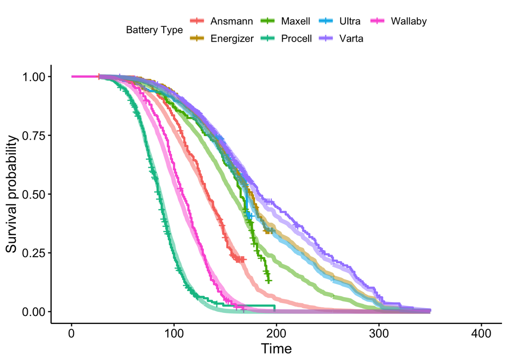

**Semi-parametric (COXPH) vs Parametric (Weibull) Survival**

The dashed lines show Weibull survival curves. The translucent thick lines show Cox Proportional-Hazard survival curves. The Weibull curves follow the Cox PH curves for the three lowest performing battery brands but show reduced survival for the four best performing brands.

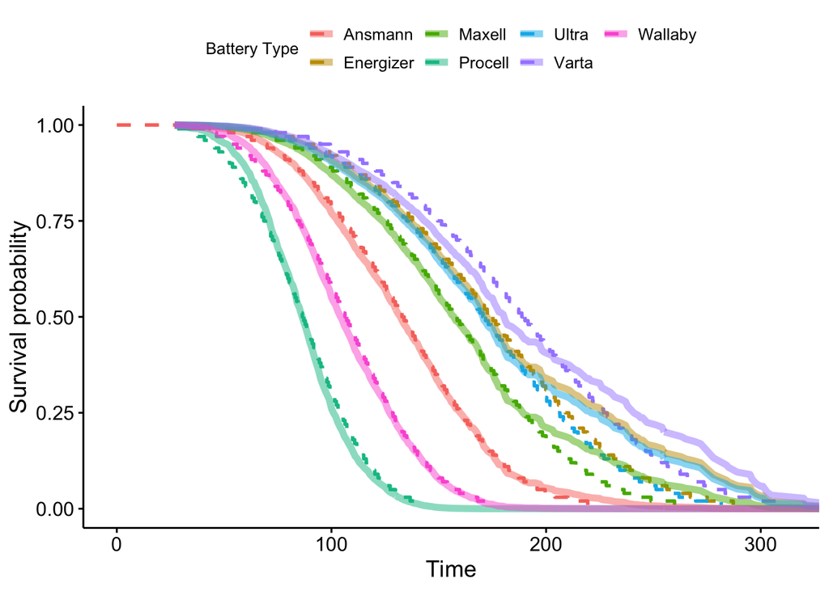

**Semi-parametric (COXPH) and Daylight Photos per Day (dpd)**

The Cox Proportional-Hazard survival curves are stratified by battery brand (colour) and the rate of daylight photos taken. The dotted, dashed and solid lines show five, fifty and ninty-five percent quartiles respectively. Incresing rate of daylight photos shows a small decrese in battery survival.

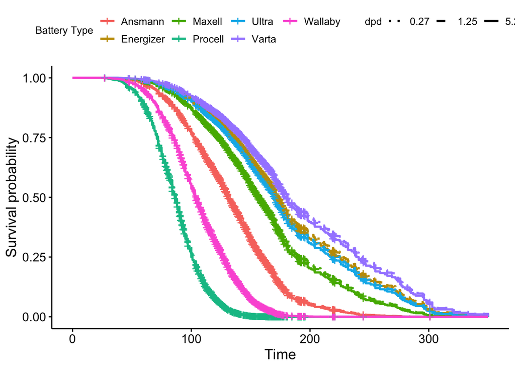

**Semi-parametric (COXPH) and Flash Photos per Day (fpd)**

The Cox Proportional-Hazard survival curves are stratified by battery brand (colour) and the rate of flash photos taken. The dotted, dashed and solid lines show five, fifty and ninty-five percent quartiles respectively. Incresing rate of flash photos shows a moderate decrese in battery survival.

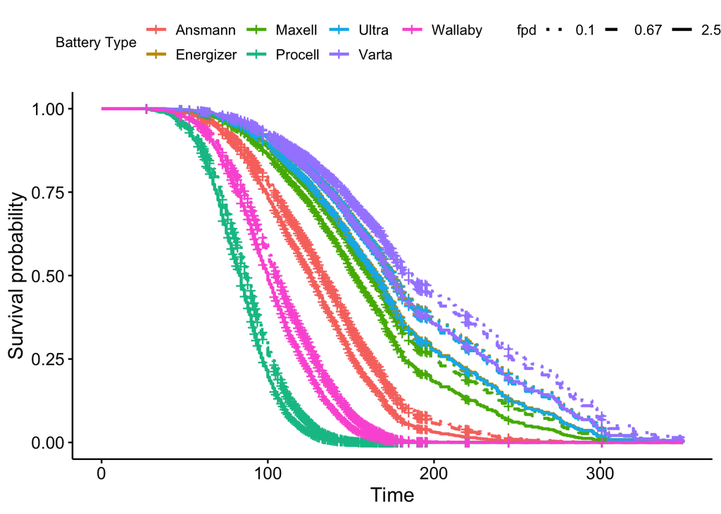

## COXPH Forest Plots

**COXPH Forest - Battery Brand, Flash Photos per Day, Daylight Photos per Day**

Battery type has a large significant effect on proportional hazard. There is a small but significant increase in hazard for flash photography.

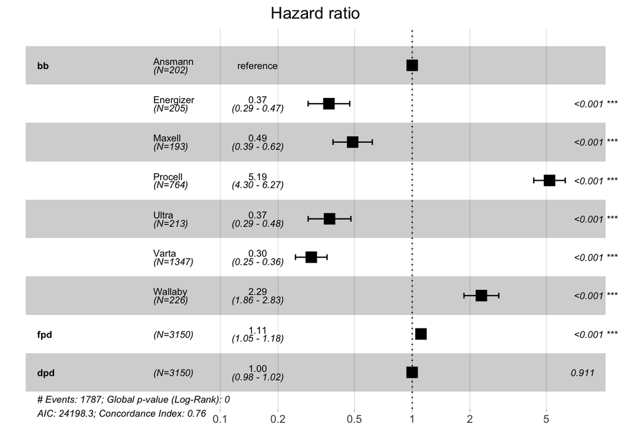

**COXPH Forest - Battery Type, Flash Photos per Day, Daylight Photos per Day**

Unsurprisingly there is a significant and large increase in hazard for akaline batteries. Oddly there is a small but significant reduction in hazard for flash photos when just considering battery type and flash type as covariates.

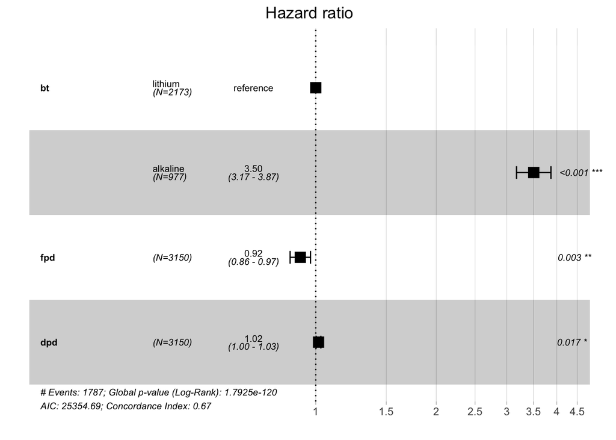

**COXPH Forest - Seasonal data with Procell and Varta brands**

There is small but significant reduction in hazard during Autumn.

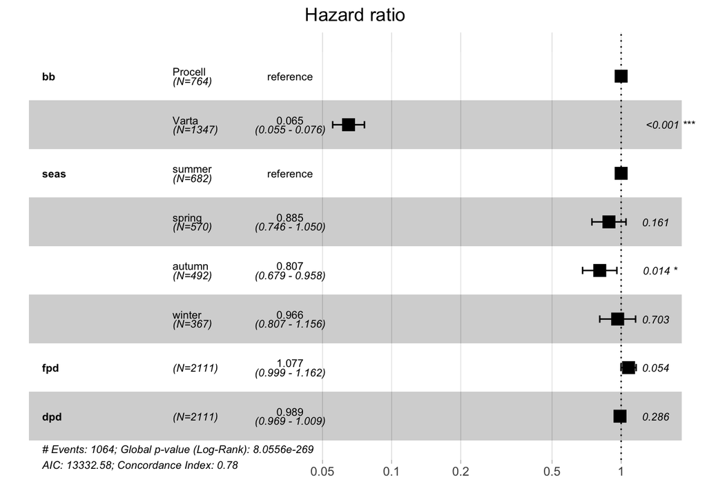

**COXPH Forest - Regional data with Varta brand**

Examining regional differences with Varta batteries, there are significant increases in hazard for the central, south east and west regions.

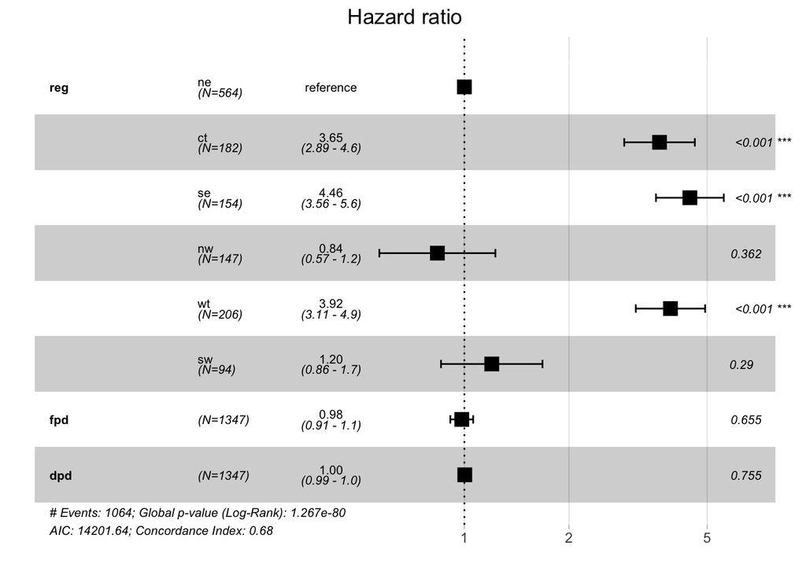